# SMekala_Assign13

Sekhar Mekala

Sunday, November 08, 2015

## Problem - 1

Given that $f(x) = x^3 + 2x^2$.

You can find the derivative of $f(x) = x^3 + 2x^2$ directly also (using the derivative formula $\frac{d(x^n)}{dx} = nx^{n-1}$) as $f'(x) = 3x^2 + 4x$.

We can use the function $f'(x) = 3x^2 + 4x$ to find the derivative of $f(x) = x^3 + 2x^2$ at any given $x$. But we will use the numerical derivative formula to find the derivative, using the following mathematical definition of derivative:

$f'(x) \approx \frac {f(x + \delta) - f(x)}{\delta}$ where $\delta$ is very close to zero.

We will build an R function called **appx_derivative()**, using the formula $f'(x) \approx \frac {f(x + \delta) - f(x)}{\delta}$. To verify our work, we will also build another function **exact_derivative()**. The **exact_derivative()** is based on the functional form of the derivative $f'(x) = 3x^2 + 4x$. Each of these functions will accept a number as input and returns the derivative value of the function $f(x) = x^3 + 2x^2$ at the given input value. Since the function is polynomial, it is continuous for all real numbers, and hence we need not check if the derivative actually exists at a given value.

### R Code for **appx_derivative()** function

We will assume $\delta$ as 1e-6 to compute the derivative of the function at a given value. This approach will give an approximate value of the derivative, at a given value.

```r
appx_derivative <- function(a){
       b = a + 1e-6

       return (((b^3+2*b^2 - (a^3 + 2*a^2))/1e-6))

  }
```

### R Code for **exact_derivative()** function

We will use the derivative obtained using the derivative formula ($f'(x) = 3x^2 + 4x$) to implement this function.

```r
exact_derivative <- function(a){

       return(3*a^2+4*a)

  }
```

### Test cases:

We will use the **appx_derivative()** function for certain numbers, and check how close are we to the acutal answer (using **exact_derivative()**) function:

```r
appx_derivative(3)
```

```
## [1] 39.00001
```

```r
exact_derivative(3)
```

```
## [1] 39
```

```r
appx_derivative(-3)
```

```
## [1] 14.99999
```

```r
exact_derivative(-3)
```

```
## [1] 15
```

```r
appx_derivative(399.111)
```

```
## [1] 479465.2
```

```r
exact_derivative(399.111)
```

```
## [1] 479465.2
```

```r
appx_derivative(399)
```

```
## [1] 479199
```

```r
exact_derivative(399)
```

```
## [1] 479199
```

The above test cases show that our approximation to derivative closely resembles the actual derivative value obtained using the functional form of derivative.

## Problem - 2

Given that $f(x) = 3x^2 + 4x$. We need to find the following: $\int_{1}^{3} 3x^2 + 4x dx$

Let us plot this function, in the given interval:

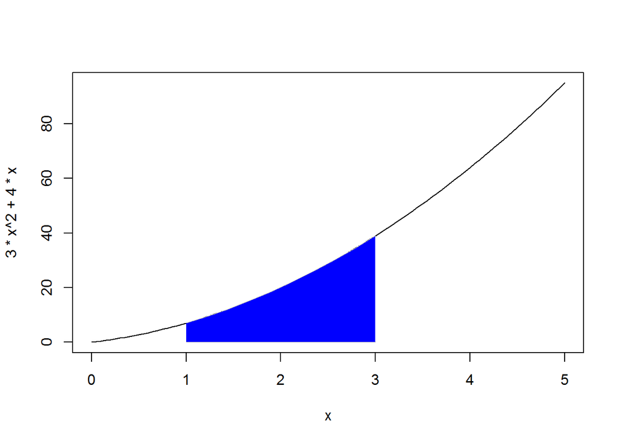

```r
curve(3*x^2 + 4*x,from=0,to=5,type="l" )

x <- seq(from=1,to=3,length=10)
y_low <- rep(0,10)
y_high <- 3*(x^2) + 4*x

lines(x,y_low,col='grey')
lines(x,y_high,col='grey')

polygon(c(x, rev(x)), c(y_high, rev(y_low)),
     col = "blue", border = NA)
```

We need to determine the shaded area size. Let us assume that this area is divided into many rectangles with the smallest width (say 1e-6), and the length of the rectangle is given by the function $3x^2 + 4x$. The sum of the areas of all such rectangles will give us the area of the shaded region, shown above.

Area of a rectangle is given by LxW (where L = length and W = width)

Therefore the area of the shaded region is given by $\sum (3x^2+4x) . \delta \mbox{ where }x \in [1,3] \mbox{ and } \delta \mbox{ is a very small value, representing the width of the rectangle}$

The following R code will evaluate this integral by the summation of all the areas of the rectangles having a width of 1e-6 and length of $3x^2+4x \mbox{where } x \in [1, (1+1^{-6}), (1+(2.10^{-6})),(1+(3.10^{-6})), .... 3]$.

```r
x = 1
area = 0
delta = 1e-6
while(x<=3)
  {

  area <- ((3*x^2+4*x) * delta) + area
  x <- x + delta

  }

print(area)
```

```
## [1] 41.99998
```

Hence the integral evaluates to 41.99998, which is approximately equal to 42.

## Problem - 3

Evaluate $\int sin(x) cos(x) dx$

**Method-1**

Let $t = sin(x)$. Differentiating on both sides with respect to $x$… $\frac{dt}{dx} = cos(x)$ $dt = cos(x) dx$

Substituting $dt$ in the place of $cos(x) dx$ and $t$ in the place of $sin(x), will make the given integral as $\int sin(x) cos(x) dx = \int (t) dt$ This evaluates to $\frac {t^2}{2} + C$ Substituting back $sin(x)$ in the place of $t$, will give us $\frac {sin^2(x)}{2} + C$

Hence, $\int sin(x) cos(x) dx = \frac {sin^2(x)}{2} + C$

**Method-2**

Integrating by parts: $\int f(x) g(x) dx = f(x) \int g(x) dx - \int f'(x) \int g(x) dx$

Hence, $\int sin(x) cos(x) dx = sin(x) \int cos(x) dx - \int \frac {d(sinx)}{dx} \int cos(x) dx$ $sin(x) sin(x) - \int cos(x) sin(x) dx$

Hence $\int sin(x) cos(x) dx = sin^2(x) - \int cos(x) sin(x) dx + C$ This can be re-written as $2 \int sin(x) cos(x) dx = sin^2(x) + C$ Hence, $\int sin(x) cos(x) dx = \frac {sin^2(x)}{2} + C$

## Problem - 4

Evaluate $\int x^2 e^x dx$ Integrating by parts, $\int x^2 e^x dx = x^2 \int e^x dx- \int 2x \int e^x dx = x^2 e^x - 2 \int x e^x dx = x^2 e^x - 2 [x \int e^x dx - \int 1 . \int e^x dx] = x^2 e^x - 2x e^x + 2e^x +C$

Therefore $\int x^2 e^x dx = x^2 e^x - 2x e^x + 2e^x +C$

## Problem - 5

Evaluate $\frac{d(xcos(x))}{dx}$

$\frac{d(xcos(x))}{dx} = \frac{d(x)}{dx} cos(x) + x \frac{d(cox(x))}{dx} = cos(x) + x (-sin(x)) = cos(x) - xsin(x)$

## Problem - 6

Evaluate $\frac{d(e^{x^{4}})}{dx}$ $\frac{d(e^{x^{4}})}{dx} = e^{x^{4}} . 4. x^3 = 4x^3 e^{x^{4}}$